# Introduction to Deep Learning

Boston, regression, hold-out validation

Rick Scavetta

## Intro

### Learning Goals

Hold-out validation

### Functions in this session:

Basic `keras` functions:

Inside the `fit()` function, there are two arguments we can use to define a simple validation set:

[output not shown]

## Part 1: Data Preparation

### Obtain data

```r
source("Boston_Z.R")
```

## Part 2: Automatic Hold-out

Automatically take X% of the training for validation.

```r
network <- keras_model_sequential() %>%
  layer_dense(units = 64, activation = "relu", input_shape = 13) %>%
  layer_dense(units = 64, activation = "relu") %>%
  layer_dense(units = 1)

# Compile as before
network %>%
  compile(
    optimizer = "rmsprop",
    loss = "mse",
    metrics = "mae"
  )

history_split <-  network %>%
  fit(
    train_data,
    train_targets,
    epochs = 120,
    batch_size = 1,
    validation_split = 0.25,
    verbose = FALSE
  )
```

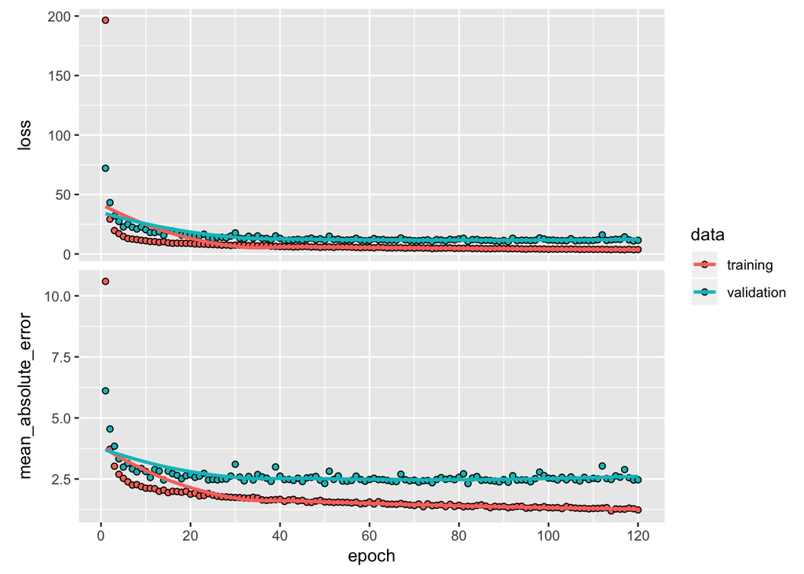

```r
plot(history_split)
```

This looks troubling… can you see why?

### Examine structure

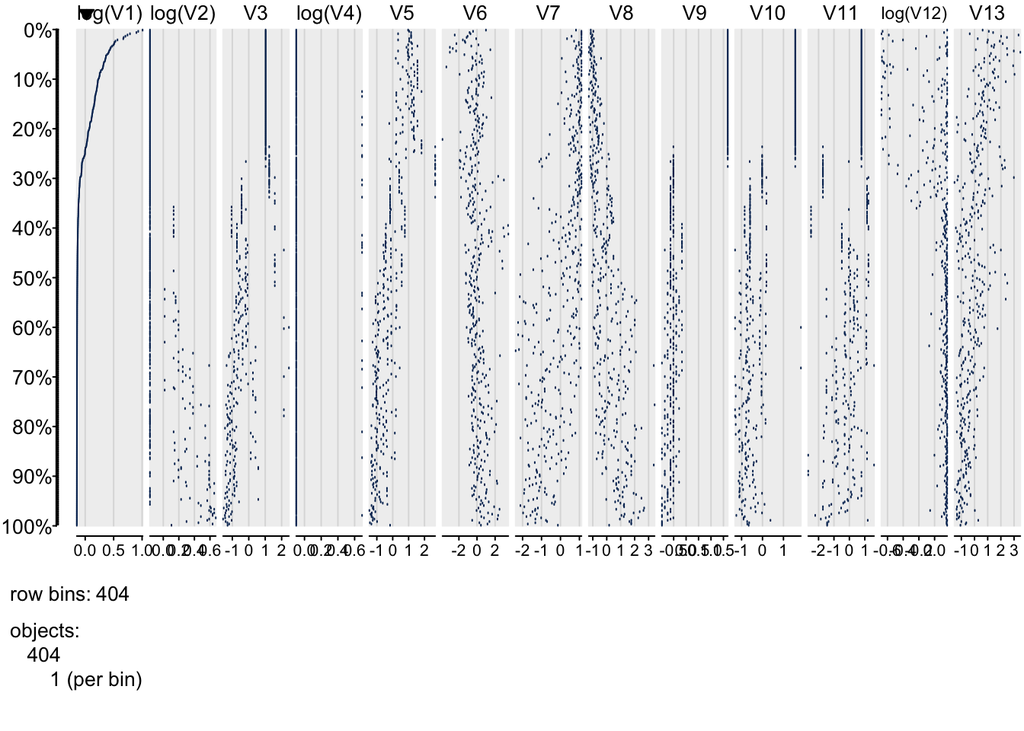

```r
library(tabplot)
tableplot(as.data.frame(train_data), nBins = 404, numMode = "ml")
```

If we’re not sure, we can manually shuffle the data beforehand:

```r
# Shuffle
train_data <- train_data[sample(1:nrow(train_data)),]

network <- keras_model_sequential() %>%
  layer_dense(units = 64, activation = "relu", input_shape = 13) %>%
  layer_dense(units = 64, activation = "relu") %>%
  layer_dense(units = 1)

# Compile as before
network %>%
  compile(
    optimizer = "rmsprop",
    loss = "mse",
    metrics = "mae"
  )

history_split_shuffle <-  network %>%
  fit(
    train_data,
    train_targets,
    epochs = 120,
    batch_size = 1,
    validation_split = 0.25,
    verbose = FALSE
  )
```

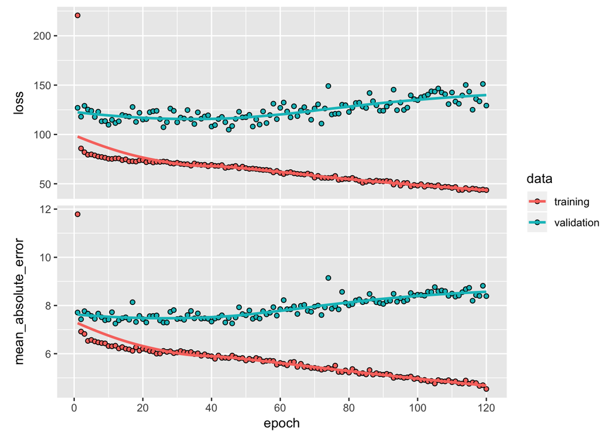

```r
plot(history_split_shuffle)
```

## Part 3: Manual Hold-out

Specify validation set manually

```r
network <- keras_model_sequential() %>%
  layer_dense(units = 64, activation = "relu", input_shape = 13) %>%
  layer_dense(units = 64, activation = "relu") %>%
  layer_dense(units = 1)

# Compile as before
network %>%
  compile(
    optimizer = "rmsprop",
    loss = "mse",
    metrics = "mae"
  )

history_data <-  network %>%
  fit(
    train_data,
    train_targets,
    epochs = 120,
    batch_size = 1,
      validation_data = list(val_data, val_targets),
      verbose = FALSE
  )
```

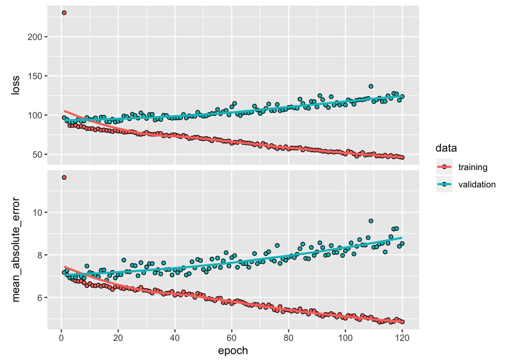

```r
plot(history_data)
```

## Part 3: k-fold Cross-validation

First, let’s make sure we have the original data, without manually splitting off a validation set:

```r
source("Boston_Z.R")
```

### Define the network as a function

In contrast to our previous case studies, we’re going to call the same model multiple times. So we’ll create a function with no arguments that we can call to create our model when ever we want to use it for training.

Here, I’ve hardcoded the number of features for this dataset (`13`). To generalize, we could just use `dim(train_data)[2]` to get the number of dimensions from the training set.

```r
build_model <- function() {
  network <- keras_model_sequential() %>%
    layer_dense(units = 64, activation = "relu", input_shape = 13) %>%
    layer_dense(units = 64, activation = "relu") %>%
    layer_dense(units = 1)

  network %>% compile(
    optimizer = "rmsprop",
    loss = "mse",
    metrics = "mae"
  )
}
```

### Define k-fold validation:

```r
k <- 4 # four groups
indices <- sample(1:nrow(train_data)) # randomize the training set before splitting for k-fold cross validation:
folds <- cut(indices, breaks = k, labels = FALSE) # divide the ordered indices into k intervals, labelled 1:k.
```

```r
num_epochs <- 40
all_scores <- c() # An empty vector to store the results from evaluation

for (i in 1:k) {
  cat("processing fold #", i, "\n")
  # Prepare the validation data: data from partition # k
  val_indices <- which(folds == i, arr.ind = TRUE)

  # validation set: the ith partition
  val_data <- train_data[val_indices,]
  val_targets <- train_targets[val_indices]

  # Training set: all other partitions
  partial_train_data <- train_data[-val_indices,]
  partial_train_targets <- train_targets[-val_indices]

  # Call our model function (see above)
  network <- build_model()

  # summary(model)
  # Train the model (in silent mode, verbose=0)
  network %>% fit(partial_train_data,
                  partial_train_targets,
                  epochs = num_epochs,
                  batch_size = 1,
                  verbose = FALSE)

  # Evaluate the model on the validation data
  results <- network %>% evaluate(val_data, val_targets, verbose = 0)
  all_scores <- c(all_scores, results$mean_absolute_error)
}
```

```
## processing fold # 1
## processing fold # 2
## processing fold # 3
## processing fold # 4
```

We get 4 MAE values, 2.6238448, 2.0319573, 2.5183405, 2.2661539, and they seem to be in the range we expected.

### Training for 250 epochs

```r
# Some memory clean-up
K <- backend()
K$clear_session()
```

Train our models, this is a pretty time-consuming task!

```r
num_epochs <- 250
all_mae_histories <- NULL # an empty object to cumulatively store the model metrics

for (i in 1:k) {
  cat("processing fold #", i, "\n")

  # Prepare the validation data: data from partition # k
  val_indices <- which(folds == i, arr.ind = TRUE)
  val_data <- train_data[val_indices,]
  val_targets <- train_targets[val_indices]

  # Prepare the training data: data from all other partitions
  partial_train_data <- train_data[-val_indices,]
  partial_train_targets <- train_targets[-val_indices]

  # Build the Keras model (already compiled)
  model <- build_model()

  # Train the model (in silent mode, verbose=0)
  history <- model %>% fit(partial_train_data,
                           partial_train_targets,
                           validation_data = list(val_data, val_targets),
                           epochs = num_epochs,
                           batch_size = 1,
                           verbose = FALSE
  )
  mae_history <- history$metrics$val_mean_absolute_error
  all_mae_histories <- rbind(all_mae_histories, mae_history)
}
```

Instead of plotting the validation loss and looking at where it starts to increase, we can also look at the validation MAE and find out at what point it stops improving. For this, we’ll calculate and plot the average per-epoch MAE score for all folds:

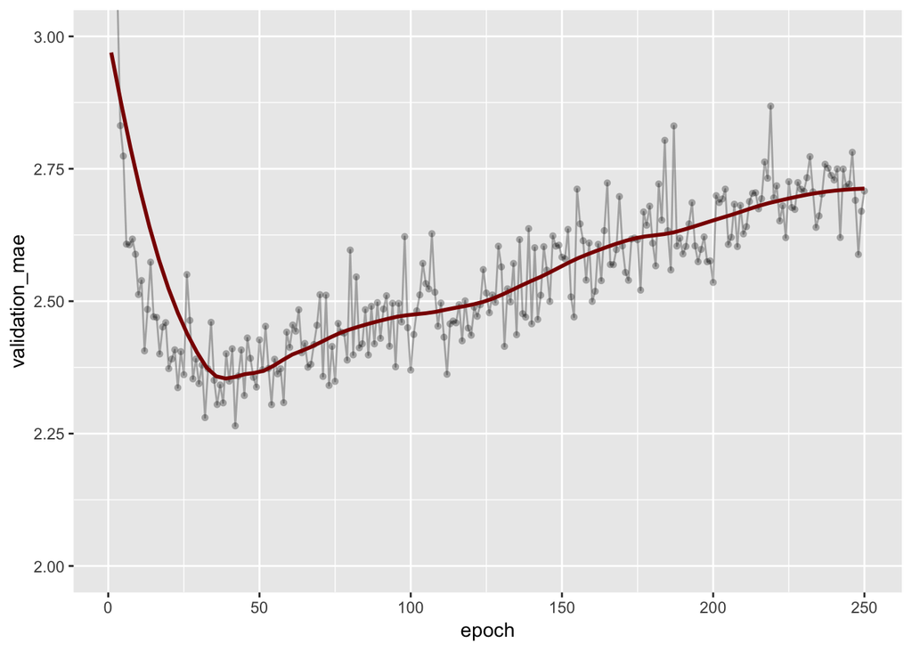

```r
average_mae_history <- data.frame(
  epoch = seq(1:ncol(all_mae_histories)),
  validation_mae = apply(all_mae_histories, 2, mean)
)

ggplot(average_mae_history, aes(x = epoch, y = validation_mae)) +
  geom_line(alpha = 0.3) +
  geom_point(shape = 16, alpha = 0.3) +
  geom_smooth(method = 'loess', se = FALSE, col = "dark red", span = 0.4) +
  coord_cartesian(ylim = c(2,3))
```

Once we are done tuning other parameters of our model (besides the number of epochs, we could also adjust the size of the hidden layers), we can train a final “production” model on all of the training data, with the best parameters, then look at its performance on the test data:

```r
result
```

```
## $loss
## [1] 16.39763
##
## $mean_absolute_error
## [1] 2.351448
```

The MAE when using k-fold cross-validation is 2.3514481. We are still off by about $2351.45. This is what we had previously, but at least now we have a good idea about why we choose this set up.

Just our of curiosity, let’s imagine we thought it was a good idea to just keep on training and training for hundreds of epochs. What would happen?